# IODS course project

Katariina

# About the project

This course is an open datascience course using Git and R. My github repository is at https://github.com/KatariinaParnanen/IODS-project

# Week 2: Data wrangling, regression analysis and model validation

This week we have learned about data wrangling using R and dplyr package. We also are introduced to basic regression analysis and model validation using diagnostic plots.

## Reading in data

We will first read in data from local directory. The data is based on a questionaire done on students of a course and their exam points.

```r
#Read in table
lrn2014<-read.table("/Users/kparnane/Documents/IODS_course/IODS-project/data/learning2014.txt", header=TRUE, sep="\t")
```

We will explore the dataset’s dimension and structure.

```r
#Explore the dimensions
dim(lrn2014)
```

```
## [1] 166   7
```

```r
#Explore the structure of the file
str(lrn2014)
```

```
## 'data.frame':    166 obs. of  7 variables:
##  $ gender  : Factor w/ 2 levels "F","M": 1 2 1 2 2 1 2 1 2 1 ...
##  $ age     : int  53 55 49 53 49 38 50 37 37 42 ...
##  $ attitude: int  37 31 25 35 37 38 35 29 38 21 ...
##  $ points  : int  25 12 24 10 22 21 21 31 24 26 ...
##  $ deep    : num  3.58 2.92 3.5 3.5 3.67 ...
##  $ surf    : num  2.58 3.17 2.25 2.25 2.83 ...
##  $ stra    : num  3.38 2.75 3.62 3.12 3.62 ...
```

The data has 166 observations and 7 variable columns.

The dataset has a response variable “points”" and explanatory variables “age”, “attitude”, “deep”, “surf” and “stra”. “deep” means points for deep learning questions, “surf” points for surface learning questions, “stra” means strategic learning techniques. “points” means exam score. More info on the dataset can be found [here](http://www.helsinki.fi/~kvehkala/JYTmooc/JYTOPKYS3-meta.txt).

## Data exploration

We will explore correlations and distributions of explanatory and response factors using “ggpairs” which plots pairwise correlations and variable disturbutions.

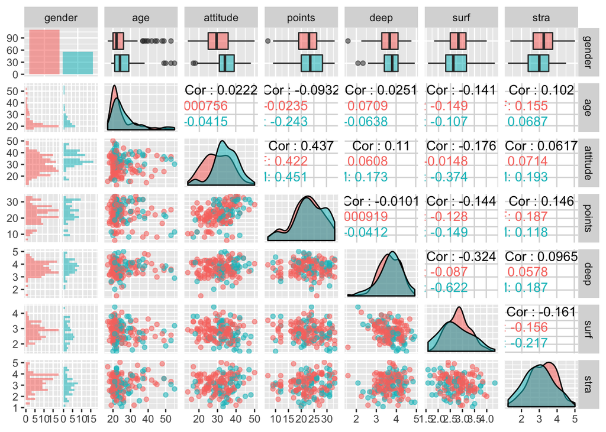

**Pairwise correlation plot**: Exploration of variables and correlations

```r
#Load required packages
library(GGally)
library(ggplot2)

#Draw plot
ggpairs(lrn2014, mapping = aes(col = gender, alpha=0.3), lower = list(combo = wrap("facethist", bins = 20)))
```

```r
#Get summaries of variables
summary(lrn2014)
```

```
##  gender       age           attitude         points           deep
##  F:110   Min.   :17.00   Min.   :14.00   Min.   : 7.00   Min.   :1.583
##  M: 56   1st Qu.:21.00   1st Qu.:26.00   1st Qu.:19.00   1st Qu.:3.333
##          Median :22.00   Median :32.00   Median :23.00   Median :3.667
##          Mean   :25.51   Mean   :31.43   Mean   :22.72   Mean   :3.680
##          3rd Qu.:27.00   3rd Qu.:37.00   3rd Qu.:27.75   3rd Qu.:4.083
##          Max.   :55.00   Max.   :50.00   Max.   :33.00   Max.   :4.917
##       surf            stra
##  Min.   :1.583   Min.   :1.250
##  1st Qu.:2.417   1st Qu.:2.625
##  Median :2.833   Median :3.188
##  Mean   :2.787   Mean   :3.121
##  3rd Qu.:3.167   3rd Qu.:3.625
##  Max.   :4.333   Max.   :5.000
```

There are more females than males. Other factors besides age seem to roughly follow a normal distribution. Mean age is 25. We are interested in the response variable points and how the explanatory variables corrrelate with it. The highest correlations are with “attitude”, “stra” and there is a negative correlation with “surf”.

## Linear models

Now we use the three variables with possible correlations with exam points identified in the data exploration in linear models.

```r
# fit a linear model
my_model <- lm(points ~ attitude+stra+surf, data = lrn2014)

# print out a summary of the model
summary(my_model)
```

```
##
## Call:
## lm(formula = points ~ attitude + stra + surf, data = lrn2014)
##
## Residuals:
##      Min       1Q   Median       3Q      Max
## -17.1550  -3.4346   0.5156   3.6401  10.8952
##
## Coefficients:
##             Estimate Std. Error t value Pr(>|t|)
## (Intercept) 11.01711    3.68375   2.991  0.00322 **
## attitude     0.33952    0.05741   5.913 1.93e-08 ***
## stra         0.85313    0.54159   1.575  0.11716
## surf        -0.58607    0.80138  -0.731  0.46563
## ---
## Signif. codes:  0 '***' 0.001 '**' 0.01 '*' 0.05 '.' 0.1 ' ' 1
##
## Residual standard error: 5.296 on 162 degrees of freedom
## Multiple R-squared:  0.2074, Adjusted R-squared:  0.1927
## F-statistic: 14.13 on 3 and 162 DF,  p-value: 3.156e-08
```

Variable “attitude” is positively correlated with points with a p-value of 1.93e-08 and estimate 0.33952. The other variables are not significantly correlated with exam points so they can be excluded from the model.

Drop the not significant variables and fit the model again.

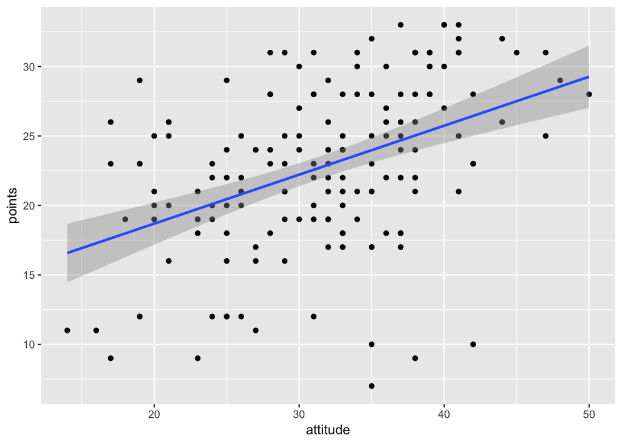

**Scatter plot with regression line**: Relationship of points and attitude

```r
# fit a linear model
my_model2 <- lm(points ~ attitude, data = lrn2014)

#Plot the regression line in scatter plot with exam points versus attitude
qplot(attitude, points, data = lrn2014) + geom_smooth(method = "lm")
```

Print summary of the model.

```r
# print out a summary of the model
summary(my_model2)
```

```
##
## Call:
## lm(formula = points ~ attitude, data = lrn2014)
##
## Residuals:
##      Min       1Q   Median       3Q      Max
## -16.9763  -3.2119   0.4339   4.1534  10.6645
##
## Coefficients:
##             Estimate Std. Error t value Pr(>|t|)
## (Intercept) 11.63715    1.83035   6.358 1.95e-09 ***
## attitude     0.35255    0.05674   6.214 4.12e-09 ***
## ---
## Signif. codes:  0 '***' 0.001 '**' 0.01 '*' 0.05 '.' 0.1 ' ' 1
##
## Residual standard error: 5.32 on 164 degrees of freedom
## Multiple R-squared:  0.1906, Adjusted R-squared:  0.1856
## F-statistic: 38.61 on 1 and 164 DF,  p-value: 4.119e-09
```

## Diagnostic plots

We will produce diagnostic plots to see if the model fits the assumptions of linear models. The assumptions are that the size of the error is not dependent on the variable value and the errors are normally distributed and that the explanatory variables are not correlated with each other. The dependent variables should also be independent from each other.

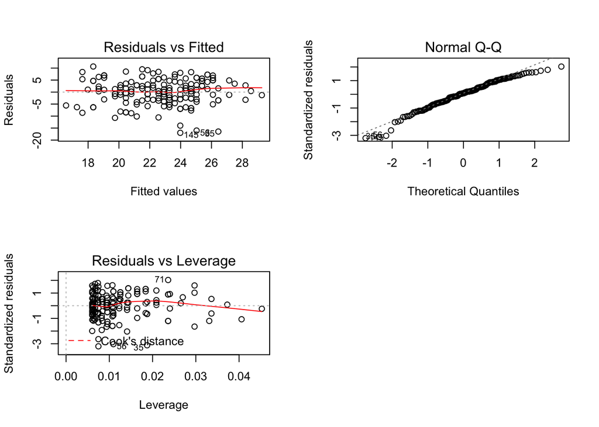

**Diagnostic plots**: Plots for exploring model errors

```r
# Draw diagnostic plots using the plot() function. Choose the plots 1, 2 and 5
par(mfrow = c(2,2))
plot(my_model2, which=c(1, 2, 5))
```

There doesn’t seem to be any patterns in the residuals vs fitted values plot so the size of the residuals are not dependent on the fitted values. The residuals in the Q-Q plot follow the assumed regression line quite well so the assumption of normal distribution of errors is filled. The residuals vs leverage plot doesn’t reveal that there are any observations which have a unusually high effect on the model. The model also has only one explanatory variable so explanatory variable autocorrelation is not a problem. The observations are also independent from each other.Thus, we can conclude that the model fits the assumptions.

# Week 3: Logistic regression

This week we have learned about logistic regression, piping and model validation.

## Reading in data

Read in data and explore.

```r
# Get access to useful libraries
library(dplyr);library(ggplot2);library(tidyr)
#Read in table from local folder
alc<-read.table(file = "data/alc.txt", sep="\t", header=TRUE)

#Explore the data using glimpse

glimpse(alc)
```

```
## Observations: 382
## Variables: 35
## $ school     <fct> GP, GP, GP, GP, GP, GP, GP, GP, GP, GP, GP, GP, GP,...
## $ sex        <fct> F, F, F, F, F, M, M, F, M, M, F, F, M, M, M, F, F, ...
## $ age        <int> 18, 17, 15, 15, 16, 16, 16, 17, 15, 15, 15, 15, 15,...
## $ address    <fct> U, U, U, U, U, U, U, U, U, U, U, U, U, U, U, U, U, ...
## $ famsize    <fct> GT3, GT3, LE3, GT3, GT3, LE3, LE3, GT3, LE3, GT3, G...
## $ Pstatus    <fct> A, T, T, T, T, T, T, A, A, T, T, T, T, T, A, T, T, ...
## $ Medu       <int> 4, 1, 1, 4, 3, 4, 2, 4, 3, 3, 4, 2, 4, 4, 2, 4, 4, ...
## $ Fedu       <int> 4, 1, 1, 2, 3, 3, 2, 4, 2, 4, 4, 1, 4, 3, 2, 4, 4, ...
## $ Mjob       <fct> at_home, at_home, at_home, health, other, services,...
## $ Fjob       <fct> teacher, other, other, services, other, other, othe...
## $ reason     <fct> course, course, other, home, home, reputation, home...
## $ nursery    <fct> yes, no, yes, yes, yes, yes, yes, yes, yes, yes, ye...
## $ internet   <fct> no, yes, yes, yes, no, yes, yes, no, yes, yes, yes,...
```

[output cut: 22 more lines]

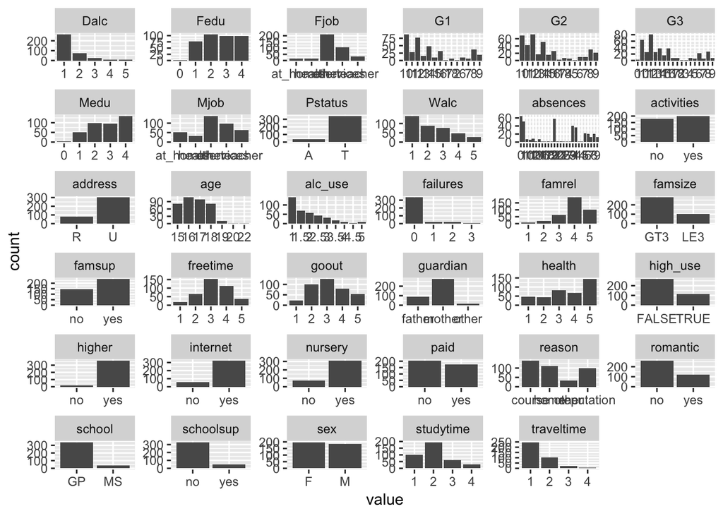

```r
# Draw a bar plot of each variable
gather(alc) %>% ggplot(aes(value)) + facet_wrap("key", scales = "free") + geom_bar()
```

The data has 382 observations and 35 variables from students whose alcohol consumption has been studied. The variables are either integers, numeric, factors or logicals. More information about the data can be found [here]https://archive.ics.uci.edu/ml/datasets/Student+Performance.

The data includes variables for sex, absences - absences from school, goout - going out and age. Usually there are differences between how much boys and girls drink due to social norms, absences from school also probably correlate with high use of alcohol, going out a lot also usually means higher alcohol consumption due to having more exposure to situations with alcohol and age might have an effect due to easier acccess to alcohol for older kids.

## Logistic regression

Logistic regression is one type of generalized linear models where the response variable can only have two values for example true or false. In this data set the response variable we are interested is high alochol use, which can have true or false values.

### Explore the relationship with high alcohol use and the chosen variables and the distribution of the variables

Explore how sex is related to high alcohol use. Our hypothesis is that males drink more than females.

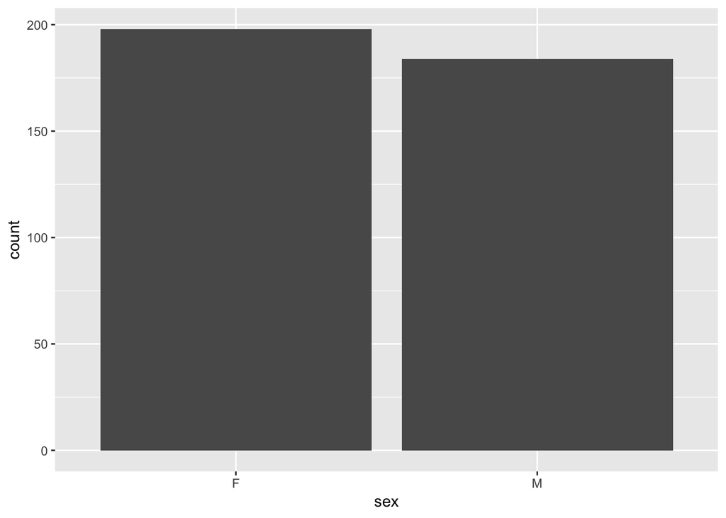

```r
#Explore the distributions of females and males in the data
g0<-ggplot(data = alc, aes(x=sex))

g0 + geom_bar()
```

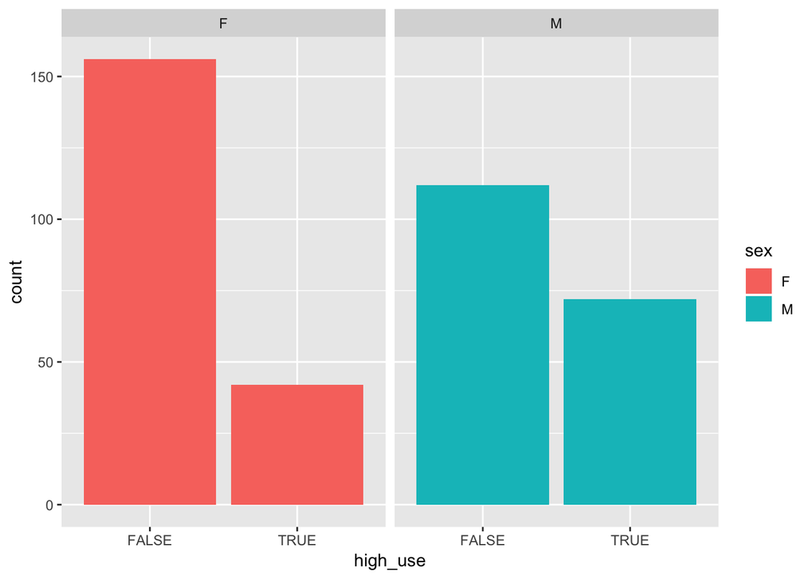

```r
#Explore how high use is dependent on sex using barplots
g1<-ggplot(data = alc, aes(x = high_use, fill = sex))

g1 + geom_bar()+facet_wrap("sex")
```

There are about equal numbers of males and females in the data. There seems to be more males who have high use compared to females, which makes sense if you think about the social norms hypothesis

Explore how absences are related to alcohol use using boxplots. Our hypothesis is that kids who are absent more are more likely to also drink more.

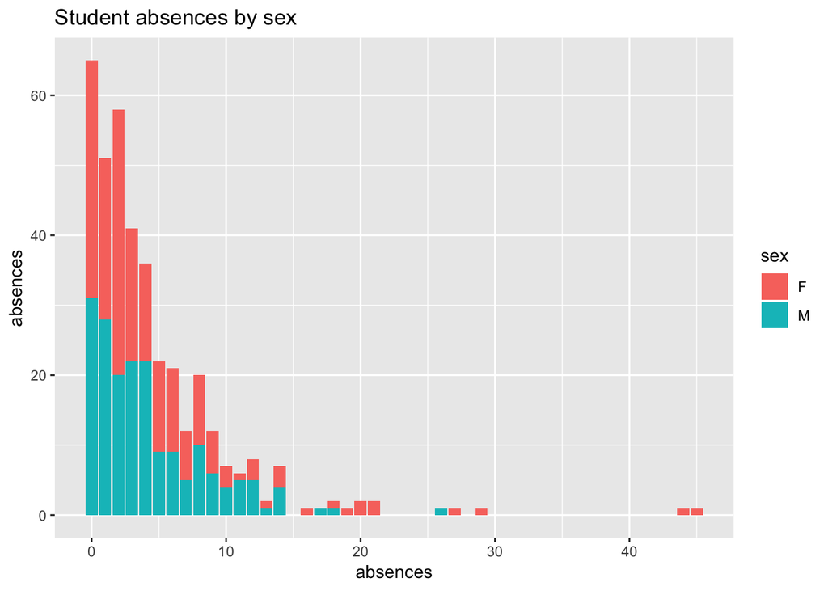

```r
# Explore the distribution of absences
g6<-ggplot(alc, aes(x=absences, fill =sex))
g6+geom_bar() + ylab("absences") + ggtitle("Student absences by sex")
```

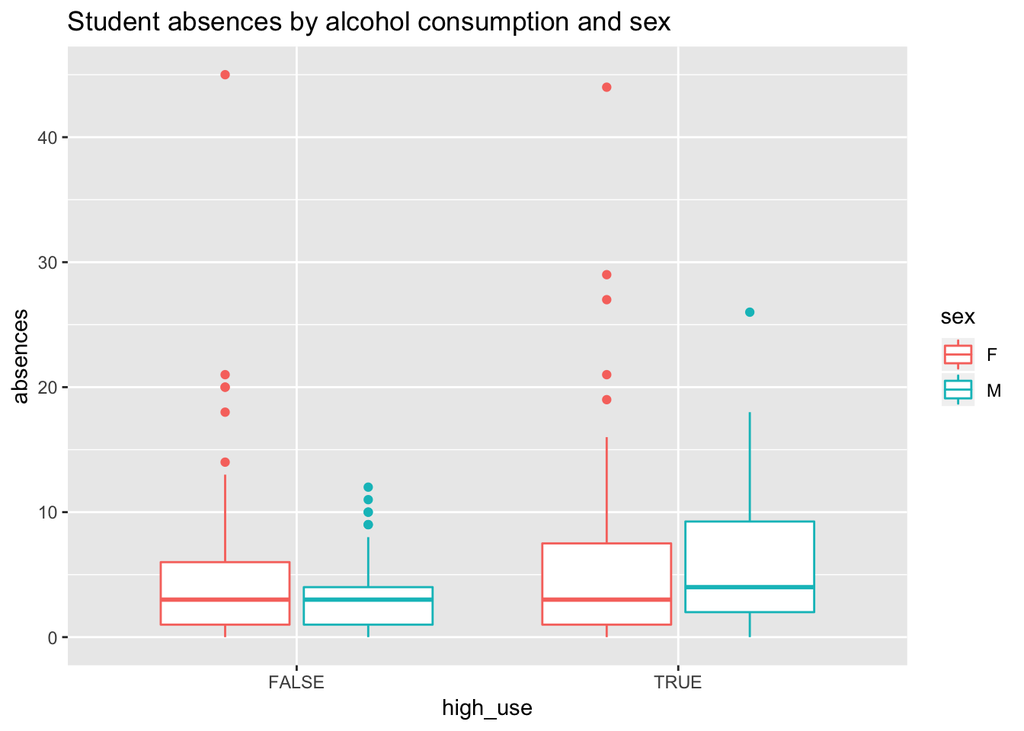

```r
#Draw boxplots with high and low alcohol uses relation with absences
g3 <- ggplot(alc, aes(x=high_use, y=absences, col = sex))
g3 + geom_boxplot() +  ylab("absences") + ggtitle("Student absences by alcohol consumption and sex")
```

Absences are not normally distributed. There is a long tail and the most common value is 0. It seems that there are more absences in the kids with high alcohol use. This makes sense if you think that kids who drink more are also skipping more school. The patterns seem similar between females and males.

Explore how going out is related to alcohol use. Our hypothesis is that kids who are going out more are exposed to alcohol more and thus will also drink more.

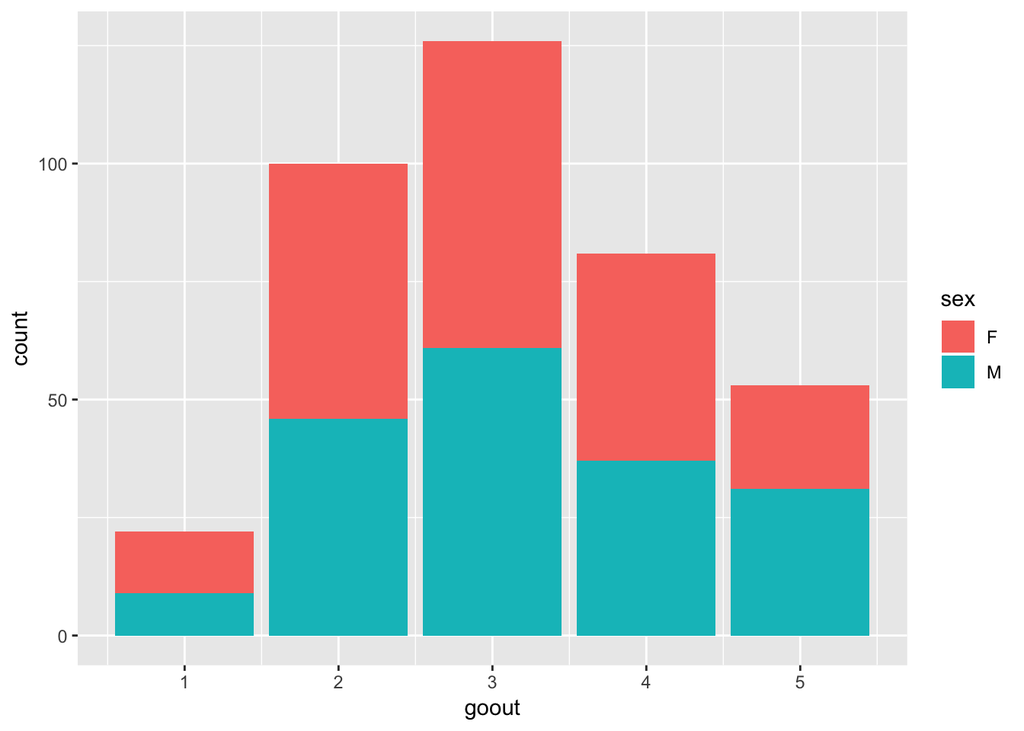

```r
#Explore the distibution of kids going out
g4 <- ggplot(alc, aes(x=goout, fill=sex))
g4 + geom_bar()
```

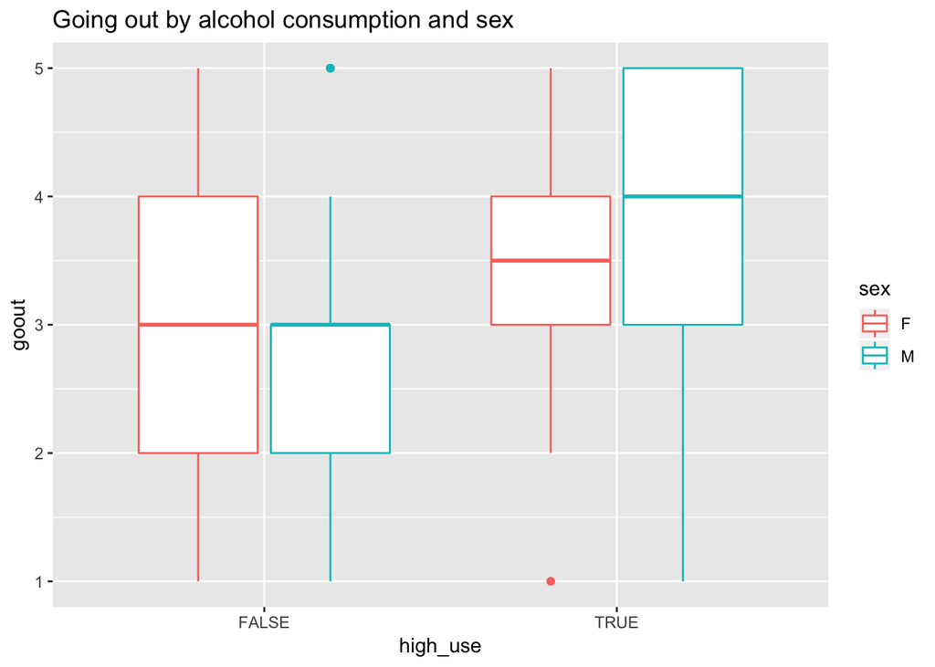

```r
#Explore the relationship with high alcohol use
g5 <- ggplot(alc, aes(x=high_use, y=goout, col = sex))
g5 + geom_boxplot()  + ggtitle("Going out by alcohol consumption and sex")
```

Going out seems to be quite normally distributed between the values 1 and 5. However, there aren’t very many kids who don’t go out almost at all compared to the ones who go out very often. There is approximately equal numbers of both sexes in each going out class.

There definitely seems to be a relationship between going out and alcohol use. However, there might be some differences between going out often beign correlated with drinking more since in females there is overlap between the ones who go out often but don’t have high alcohol use with those who go out often and have high alcohol use.

Explore the relationship with age and alcohol use. Our hypothesis is that it is easier for older kids to get alcohol than for younger kids.

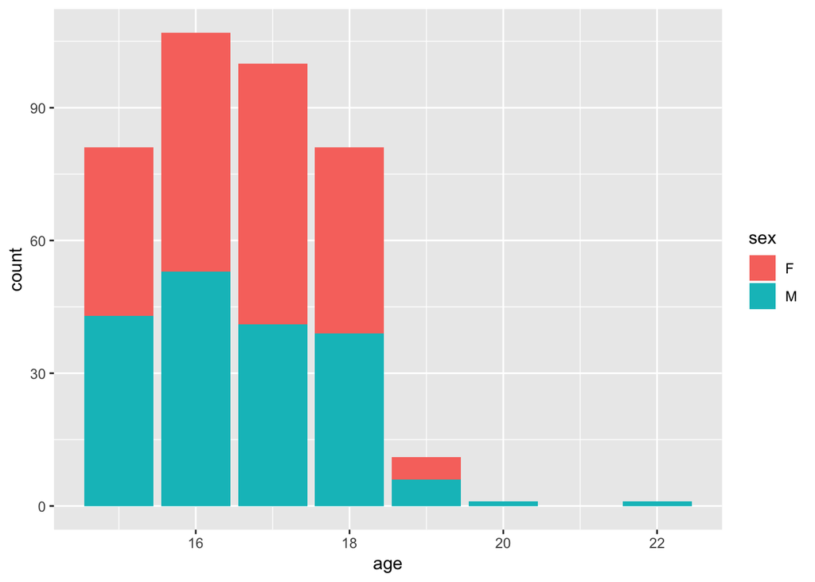

```r
# Explore the distribution of age
g6<-ggplot(alc, aes(x=age, fill =sex))
g6+geom_bar()
```

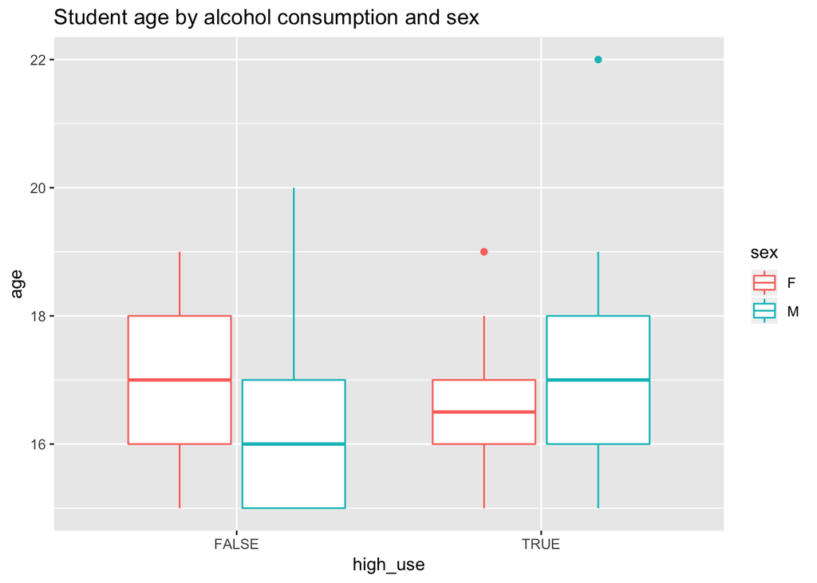

```r
# Explore the relationship of age  with alcohol use

g7 <- ggplot(alc, aes(y=age, x=high_use, col = sex))
g7 + geom_boxplot() + ylab("age") + ggtitle("Student age by alcohol consumption and sex")
```

There doesn’t seem to be a very obvious link between alcohol use and age that could be seen from the boxplots since the high use boxplots overlap with the low use bowplots. It might be that it is not very difficult to get alchol in the country of the kids even when you are younger than 18.

### Build model with the variables that seemed interesting

Next we will build a GLM using binomial family with the interesting explanatory variables.

```r
# Use generalized linear models to predict high use based on selected variables

m<-glm(high_use~age+sex+absences+goout, data=alc, family = "binomial")

#Print out summary and coefficients
summary(m)
```

```
##
## Call:
## glm(formula = high_use ~ age + sex + absences + goout, family = "binomial",
##     data = alc)
##
## Deviance Residuals:
##     Min       1Q   Median       3Q      Max
## -1.7877  -0.8026  -0.5393   0.8294   2.5201
##
## Coefficients:
##             Estimate Std. Error z value Pr(>|z|)
## (Intercept) -5.60333    1.84395  -3.039 0.002376 **
## age          0.08951    0.11003   0.814 0.415905
## sexM         0.96338    0.25490   3.779 0.000157 ***
## absences     0.08205    0.02247   3.651 0.000261 ***
## goout        0.71753    0.12058   5.951 2.67e-09 ***
## ---
## Signif. codes:  0 '***' 0.001 '**' 0.01 '*' 0.05 '.' 0.1 ' ' 1
##
## (Dispersion parameter for binomial family taken to be 1)
##
##     Null deviance: 465.68  on 381  degrees of freedom
## Residual deviance: 387.09  on 377  degrees of freedom
## AIC: 397.09
##
## Number of Fisher Scoring iterations: 4
```

```r
#From the summary we can see that sex, absences and going out are significantly correlated with high alcohol use

coef(m)
```

```
## (Intercept)         age        sexM    absences       goout
## -5.60333157  0.08951186  0.96338497  0.08204599  0.71752626
```

```r
#From the coefficients we can calculate the odds ratio by taking the exponent function of the estimate


# compute odds ratios (OR)
OR <- coef(m) %>% exp

# compute confidence intervals (CI)
CI<- confint(m) %>% exp
# Join the two together

cbind(OR, CI)
```

```
##                      OR        2.5 %    97.5 %
## (Intercept) 0.003685565 9.268741e-05 0.1296785
## age         1.093640305 8.815211e-01 1.3582243
## sexM        2.620551969 1.599662e+00 4.3546202
## absences    1.085505735 1.040056e+00 1.1371493
## goout       2.049357367 1.626970e+00 2.6130756
```

## Cross validation

After obtaining the model, we will use cross validation with a training set to estimate the error rate of the model. We will use the model without age since age was not significant.

```r
# Fit the model without age
m<-glm(high_use~sex+absences+goout, data=alc, family = "binomial")


# Predict the probability of high alcohol use
probabilities <- predict(m, type = "response")

# Add the predicted probabilities to the alc table
alc <- mutate(alc, probability = probabilities)

# Use the probabilities to make a prediction of high alcohol use as probabilitites instead of odds
alc <- mutate(alc, prediction = probabilities>0.5)

# See the last ten original classes, predicted probabilities, and class predictions
select(alc, failures, absences, sex, high_use, probability, prediction) %>% tail(10)
```

```
##     failures absences sex high_use probability prediction
## 373        1        0   M    FALSE  0.14869987      FALSE
## 374        1        7   M     TRUE  0.39514446      FALSE
## 375        0        1   F    FALSE  0.13129452      FALSE
## 376        0        6   F    FALSE  0.18714923      FALSE
## 377        1        2   F    FALSE  0.07342805      FALSE
## 378        0        2   F    FALSE  0.25434555      FALSE
## 379        2        2   F    FALSE  0.07342805      FALSE
## 380        0        3   F    FALSE  0.03989428      FALSE
## 381        0        4   M     TRUE  0.68596604       TRUE
## 382        0        2   M     TRUE  0.09060457      FALSE
```

```r
# From here you can see than when prob is >0.5 the prediction is "TRUE"

# Cross tabulate the target variable versus the predictions
table(high_use = alc$high_use, prediction = alc$prediction) %>% prop.table %>% addmargins()
```

```
##         prediction
## high_use      FALSE       TRUE        Sum
##    FALSE 0.66230366 0.03926702 0.70157068
##    TRUE  0.17015707 0.12827225 0.29842932
##    Sum   0.83246073 0.16753927 1.00000000
```

```r
# From here we can see that out of 65/318 predictions are wrong for predicted low alcohol use and 15/64 are wrong for the prediction of high alcohol use.

# Define a loss function to get the mean prediction error
loss_func <- function(class, prob) {
  n_wrong <- abs(class - prob) > 0.5
  mean(n_wrong)
}

# Call loss_func to compute the average number of wrong predictions in the (training) data
loss_func(class = alc$high_use, prob = alc$probability)
```

```
## [1] 0.2094241
```

```r
# Do K-fold cross-validation using the loss_func defined previously
library(boot)
cv <- cv.glm(data = alc, cost = loss_func, glmfit = m, K = 10)

# Average number of wrong predictions in the cross validation
cv$delta[1]
```

```
## [1] 0.2146597
```